# Module 11: Exploratory Data Analysis, Part 2: Static Data Visualizations

## DS 6001: Practice and Application of Data Science

**Table of contents**:

- Introduction: What Makes For a Good Data Visualization?
  - Aesthetics, Data, and Scales
  - Edward Tufte's "Fundamental Principles of Analytical Design"
  - Claus O. Wilke's Guide to Telling a Story and Making a Point
  - How (not) to Lie with Statistics
  - Why Not Pie Charts?
- Creating Data Visualizations in Python
  - Barplots and How to Use `matplotlib`, `seaborn`, and the Dataframe `.plot()` Method
    - Vertical and Horizontal Barplots, Figure Size, Labels, Titles, and Colors
    - Barplots for Statistics Other Than Frequencies
    - Annotating Bars with Values
    - Grouped and Stacked Bars
    - Placing Graphs Within Grids
    - Saving a Figure as a Local File
  - Scatterplots
    - Using Colors, Shapes, and Transparency to Annotate Scatterplots
    - Including Lines of Best Fit
    - Scatterplot Grids and Matrices
  - Line Plots
  - Distributional Graphs
    - Histograms
    - Density Plots
    - Violin Plots
    - Boxplots
  - Heatmaps

## Introduction: What Makes For a Good Data Visualization?

Data visualizations are graphical representations of distributions and relationships in the data. They are essential tools for exploratory data analysis (EDA), and they are important ways to communicate the results of statistical and machine learning models. In [Exploratory Data Analysis](https://www.google.com/books/edition/_/TpYOvgEACAAJ?hl=en&sa=X&ved=2ahUKEwjFz6afxbbqAhVdoHIEHdCjDXgQ7_IDMBB6BAgNEAI), John W. Tukey argues that visualizations help us to see not only problems in the data, but also can reveal patterns that theory alone never would have led us to examine.

Visualizations are among the best tools we have for communication. Data and statistics can be technical and dependent on terminology and jargon that are inaccessable without a great deal of training. If we need to show our data and our results to a manager, to a client, to the public, or to another audience, we can use visualizations to quickly and clearly tell the stories that the evidence in our data supports. Pictures are also efficient: even if someone can understand a technical discussion, a good picture can convey the information more quickly than a table, and more accurately as well because we can better express the context surrounding a result with a visualization.

But like any mode of communication, there are more effective and less effective ways to visualize data. Some visualizations are confusing. Other visualizations are misleading. Our goal is to create graphics that tell a clear story that a general audience can quickly understand while taking steps to ensure that the data are presented accurately and in a way that does not mislead.

There are degrees of completion when designing a visualization. For the purposes of EDA, we ourselves might be the audience, so we can spend less time on writing descriptive labels and choosing the most aesthetically pleasing colors, shapes, and sizes for graphical elements. We can stick to defaults more often even if the defaults are ugly, or when they might be misunderstood by someone else. These exploratory graphics can accomplish Tukey's goals for EDA: finding anomolies and problems in the data and revealing unexpected patterns. If our purpose is to use the graphic to communicate with an audience, however, then we will take steps to improve the labels and aesthetic elements of the visualization.

There are many words for a data visualization. In the following discussion, we will use the words visualization, graphic, graph, plot, and figure interchangably.

### Aesthetics, Data, and Scales

In chapter 2 of [Fundamentals of Data Visualization](https://serialmentor.com/dataviz/), Claus O. Wilke explains that a data visualization has three parts: aesthetics, data, and scales. Aesthetics are the visual elements of graphic: the axes, the plot area, the shapes and colors of different sizes that appear in the plot area, and the labels. Scales are functions that map the data we are trying to describe to aesthetics. For example, in a **scatterplot**, we illustrate the relationship between two continuous-valued features by setting the values of each feature to be the x and y coordinates of a point to be plotted on a Cartesian plane.

[figure not shown]

Two examples of scatterplots: alcohols by hatred for self and for others, according to Zach Weinersmith (source: https://www.smbc-comics.com/comic/self-destructive-beverages), and the tastiness and difficulty of eating various fruits according to Randall Munroe (Source: https://xkcd.com/388/)

The coordinates of the points are the data, and the rule that sets the data as the x and y coordinates is the scale. In Randall Munroe's scatterplot, he plots the fruit by scores he gives each fruit for tastiness and for difficulty. In Zach Weinersmith's scatterplot, he determines the amount of hatred someone must have for themselves and for others in order to drink each of the alcohols. Although both are subjective and funny, there is underlying data represented in each graph, and the scale sets the points at the coordinates defined by the data. Aesthetics include the choice of shape for each point - a small hollow circle, a solid circle, squares, triangles, or another shape such as pictures of fruits - as well as the size, color, and transparency of the points. The aesthetics also include elements beyond the points: the color of the plot area, whether to include vertical and horizontal guiding lines in the background, the range of the axes, how to label the axis values (if at all), the axis labels, whether to include a legend, and the title of the graph.

When constructing a visualization, the part of the graph we select first is the data. We have to acquire the data we need and manipulate the data so that we can perform EDA. Second, we choose the scale. The scales are generally set by the type of graph we choose. Every scatterplot, for example, sets the two features as the coordinates of each point, and every barplot sets the height of the bars equal to the calculated frequency (or a different descriptive statistic) for each category. Once we choose a graph, we won't be able to change the way data is mapped to aesthetics. Finally, once we've set the data and the scales of the graph, we can choose the aesthetics. Most of the guidance that exists regarding how to create an effective visualization focuses on the choice of graph type, which implies the scales, and on the aesthetics.

### Edward Tufte's "Fundamental Principles of Analytical Design"

[Edward Tufte](https://en.wikipedia.org/wiki/Edward_Tufte) is a statistician, computer scientist, and political scientist who became well known for writing guiding principles for data visualization, beginning with his book [The Visual Display of Quantitative Information](https://www.edwardtufte.com/tufte/books_vdqi). Today he travels the country, teaching one-day (expensive) [short courses](https://www.edwardtufte.com/tufte/courses) on the topic of data visualization. He is a notorious [critic of Microsoft Powerpoint](https://www.edwardtufte.com/bboard/q-and-a-fetch-msg?msg_id=0001yB&topic_id=1), and he coined the term [chartjunk](https://en.wikipedia.org/wiki/Chartjunk) to refer to "all visual elements in charts and graphs that are not necessary to comprehend the information represented on the graph, or that distract the viewer from this information."

In [Beautiful Evidence](https://www.edwardtufte.com/tufte/books_be), Tufte presents six "Fundamental Principles of Analytical Design" (p. 122) which guide the choices visualization designers should make when choosing graph types and aesthetics. First, graphics must show "comparisons, contrasts, [or] differences" in the data (p. 127). A scatterplot shows differences between each of the rows in the data on the features that comprise the coordinates. A barplot compares one category of a feature to another on some dimension.

Second, graphs must show "causality, mechanism, explanation, [or] systemic structure" (p. 128). If the goal is to describe the relationship between two features, then an accurate portrayal of that relationship might be considered causal or an explanation if we take additional steps to account for confounding factors and if we are careful to correctly state which feature is the cause and which is the effect. If we cannot rise to the level of making a causal statement, then showing a relationship is still an illustration of the mechanism or systemic structure in the covariance of the features. Regardless of the reason for a correlation, a correlation exists and can be visualized.

Third, figures can and should "show multivariate data; that is, show more than 1 or 2 [features]" (p. 130). Different aesthetics make it possible for us to include more than two variables in one visualization. For example we can create a scatterplot in which the x-values represent people's ages and the y-axis represents people's personal incomes. We can change the colors of each point to represent each person's gender, and we can use the shape of each point to represent the person's political party affiliation. Other writers, including Wilke, caution against including too many features in one graphic as each additional feature makes the figure more confusing. Our goal should be to show as much of the data as possible without increasing the complexity of the figure too much.

Fourth, visualizations should "integrate words, numbers, [and] images (p. 131). We can annotate graphs with words or numbers: for example, by labeling points in a scatterplot, as in both the fruit and alcohol scatterplots shown above, or by labeling bars in a barplot with the height of each bar. We can use images as well, for example by placing images of flags onto bars in a barplot that shows cross-national differences.

Fifth, graphics should be presented along with documentation to help the audience understand the meaning of various aesthetic elements. If we use colors to mark points in a scatterplot as representing a woman or a man, then there should be an accompanying legend that makes the colors' meanings clear. We can also use captions underneath a figure and explanatory text to make sure that all the distinct mappings from data to aesthetics are understandable.

Finally, Tufte holds the following principle above all of the others:

> Analytical presentations ultimately stand or fall depending on the quality, relevance, and integrity of their content.

(p. 136). In other words, all of the work we've done to acquire and manipulate data is necessary for effective visualizations to be possible. If we have not collected high quality data, or if we have not properly cleaned the data, then no amount of attention paid to a figure's aesthetics will make the figure into a worthwhile tool for communicating distributions and relationships in the data.

### Claus O. Wilke's Guide to Telling a Story and Making a Point

We can use data visualizations to communicate findings within a dataframe to an outside audience. But we want the information contained within a visualization to be understood and remembered, and people in general do not process highly abstract information quickly, and they do not tend to remember it.

In chapter 29 of [Fundamentals of Data Visualization](https://serialmentor.com/dataviz/), Claus O. Wilke recommends thinking about a crafting a narrative when constructing a data visualization. People understand and remember stories. Using a story to motivate and explain a visualization does not mean that we misrepresent the findings, but rather that we use the frame of a story to describe the findings, why they are important, and what the larger take-away points should be.

A [narrative arc](https://blog.reedsy.com/narrative-arc/) describes the organization and sequence of a story. The most well-known model of a narrative arc is Gustav Freytag's pyramid: Exposition, Rising Action, Climax, Falling Action, and Denouement. An academic paper or a data analysis report can follow this model as well. The artcle begins with a statement of the topic and the research question (the exposition). The literature review reveals the unaddressed areas in which a novel contribution can be made (the rising action). The results provide an answer to the research question (the climax), and a subsequent discussion places the results in the larger context of the literature and describes further implications (falling action). The conclusion summarizes the most important points of the article (the denouement).

There are other models for narrative arcs other than Gustav Freytag's. Kurt Vonnegut states:

> There's no reason why the simple shapes of stories can't be fed into computers. They are beautiful shapes.

In the following talk, Vonnegut maps out the narrative arc of many different stories:

```python
from IPython.display import IFrame
IFrame(src="https://www.youtube.com/embed/oP3c1h8v2ZQ", width="560", height="315")
```

Regardless of the specific model used to describe a story, stories should have a beginning, middle, and an end, and should set up a conflict (a research question) and resolve that conflict (with our findings). If we keep this structure in mind, we can prepare an audience to see our findings with other visualizations that help people understand the problem, and we can use visualizations to convey both our findings and their elaborations and implications.

If we think about visualizations as a means to tell a story, Wilke recommends that that we take steps to make the visualizations understandable and memorable. Although Tufte encourages us to include more than one or two features in a single figure, each additional feature makes it harder to understand the stories that other features describe. Wilke suggests that we think about the main take-home points we want our audience to understand, and to reduce the features in a single visualization to only those that speak directly to this story. He writes: "Never assume your audience can rapidly process complex visual displays." That's true both of general audiences and of audiences of people with specific technical training: complicated figures cause everyone to tune out.

Suppose that we create ten barplots with exactly the same formatting. Even if each of the ten plots are perfectly understandable and clear the points that each one makes may be lost in the noise of repeated, similar images. Wilke notes that it is important to make the figures more memorable by making them more distinct. First we can use color to highlight specific elements of a figure to emphasize points that are more important to the story. If one category among the bars is of special interest to us, we can use one color for that bar and a different color for all the others. If elements of the plot represent units with well-known images, we can use these images on the graph the way Randall Munroe uses pictures of fruits instead of points. These extra visual elements will make each figure stand out and be more memorable.

### How (not) to Lie with Statistics

[How to Lie with Statistics](https://books.google.com/books/about/How_to_Lie_with_Statistics.html?id=5oSU5PepogEC) by Darrell Huff is a short, funny, and classic book that describes many ways that statistics can be used to mislead an audience. The book was written in 1954, and has been reprinted many times since then.

[figure not shown]

- The Gee-Whiz Graph: a figure that manipulates the range of the y-axis to make it seem like a feature changes more or less than it actually does.
- The One-Dimensional Picture: a graph that maps data to the height of images, but uses non-rectuangular shapes to increase the area by a greater proportion than the difference in heights.

The idea of a one-dimensional picture is related to Wilke's discussion of the principle of proportional ink in chapter 17 of [Fundamentals of Data Visualization](https://serialmentor.com/dataviz/). The principle of proportional ink is

> The sizes of shaded areas in a visualization need to be proportional to the data values they represent.

With a barplot, the images we use to represent the data are rectangles. If we double the height of a rectangle, we also double the area of a rectangle:

$$ (2 \times \text{height})(\text{width}) = 2\times(\text{height})(\text{width}) = 2\times(\text{area})$$

The principle of proportional ink is violated when doubling the height causes the area to increase by a factor other than 2. The human eye recognizes area first, so if the data are represented by the height, a change in area by a different factor misrepresents the data. Barplots do not violate the principle of proportional ink because of the specific property of rectangles that the height and area change with the same proportion. The same thing is not true of other shapes. For example, Darrell Huff uses the following image to represent a one-dimensional picture:

[figure not shown]

An illustration of a violation of the principle of proportional ink. (Source: How to Lie with Statistics, p. 69).

The data that are represented in this figure are monetary amounts, represented by the height of each money bag. The money bag on the right is twice the height of the money bag on the left. But because these shapes are not rectangles, the area of the money bag on the right is more than double the size of the money bag on the right. A figure like this conveys the incorrect notion that the money bag on the right is larger than it is.

When creating data visualizations, it is important to represent the data accurately by using a reasonable scale for the y-axis (generally by including 0 in this scale), and by using rectangular area to ensure that the principle of proportional ink is not violated.

### Why Not Pie Charts?

We will not be discussing the methodology to create pie charts. In general pie charts are considered poor ways to represent data, and many statisticians and data scientists bemoan the prevalence of pie charts in government and business. Walt Hickey, writing for [Business Insider in 2013](https://www.businessinsider.com/pie-charts-are-the-worst-2013-6?op=1), phrases his opinion of pie charts in no uncertain terms:

> The pie chart is easily the worst way to convey information ever developed in the history of data visualization.

Hickey's argument reflects the argument of many statisticians and data scientists. First, if the goal of a data visualization is to present data in a clear way, pie charts can obscure the data because the human eye can measure distance better than angles. The following data can be represented in pie charts or barplots:

[figure not shown]

The same data represented in pie charts then in barplots. (Source: Walt Hickey, "The Worst Chart in the World", https://www.businessinsider.com/pie-charts-are-the-worst-2013-6?op=1).

In the pie charts, the five quantities are represented by the angles in the slices of the circle. But it is hard to determine how much larger or smaller each slice is relative to the others, and sometimes it is hard to determine which of the slices is largest and smallest. In contrast, this information is clear in the barplots. Pie charts are often annotated by the numbers that each slice represents, but if the labels are necessary to read a pie chart then the chart itself is not needed as a reader can look at the labels alone.

Pie charts do uphold the principle of proportional ink because the area of a slice of a circle is given by the formula $$ \text{area} = \frac{\theta}{360}(\pi r^2) $$ where $\theta$ is the angle of the slice and $r$ is the radius of the circle, which is constant for all slices. If we double the angle $\theta$, the area also doubles because: $$ \frac{2 \times\theta}{360}(\pi r^2) = 2 \frac{\theta}{360}(\pi r^2) = 2(\text{area}).$$ However, a common variant is a 3D piechart, as in the following example:

[figure not shown]

A 3D pie chart (Source: Walt Hickey, "The Worst Chart in the World", https://www.businessinsider.com/pie-charts-are-the-worst-2013-6?op=1).

Because of the added base, 3D pie charts violate the principle of proportional ink. Notice that the light-blue slice on top of the circle has a larger angle than the red slice on the bottom, but more ink is devoted to the red slice than the light-blue one because of the perspective in the drawing. In addition, the tilted perspective turns the circle into an oval, which expands the angles on the top and bottom and compresses the angles on the sides. A 3D pie chart is misleading and confusing and should never be used.

There is one advantage of a pie chart. Pie charts show the proportion of each category to the total across categories, which barplots do not. That's useful when the story we are trying to tell is that one category is much larger than all of the others and dominates the total when adding up all the slices. The following figure is one of the best examples of a pie chart:

[figure not shown]

Military spending by country (Source: Wikipedia https://en.wikipedia.org/wiki/List_of_countries_by_military_expenditures).

In this figure, the story is that the United States spends much more on defense than any other country, and that China also spends more than any other country with the exception of the United States. Together the United States and China account for nearly half of the world's defense spending. This pie chart is effective at making these points, but it is not effective at illustrating specific country-to-country comparisons without the numeric annotations.

## Creating Data Visualizations in Python

There are many distinct styles of data visualization that are well-suited for different kinds of data. Within these styles, there are many adaptions with different aesthetics. Each style involves fixing the scale - the function that maps data to aesthetics - of the visualization, so if we choose a barplot, for example, the height of the bars (or the length of the bars if the bars are oriented horizontally) are determined by the data we are trying to plot.

The five most important types of data visualization are **barplots, scatterplots, line plots, distributional plots, and heatmaps**. There are many examples of each type later in this chapter.

These visualizations can also be combined. For example, a scatterplot might attach histograms to the edges of the plot area that are opposite the x and y-axes to show the histograms for each of the two features in the scatterplot. There are other kinds of data visualizations as well, such as network plots to show the connections between nodes in a network. However, in this chapter we will only focus on the visualizations described above.

The following discussion illustrates the code to generate barplots, scatterplots, line plots, distributional plots, and heat maps using the `matplotlib` and `seaborn` packages in Python, as well as using the `.plot()` method from `pandas`. For each of these plots, we can change the aesthetics to change the appearance of the plot and include additional features in the plot. We will alter the aesthetics as needed to produce good-looking, accurate, and understandable visualizations. This discussion is not meant to be a comprehensive list of visualizations, but an introduction to the major coding systems available for plotting in Python. For more examples, see the `matplotlib` [image gallery](https://matplotlib.org/gallery.html) or the `seaborn` [example gallery](https://seaborn.pydata.org/examples/index.html).

We can generate visualizations using `matplotlib` or `seaborn`, so how do we know which one to use? In what situations is one package better than the other?

The trickiest thing about visualization in Python is that `matplotlib`, `seaborn`, and the `.plot()` method in `pandas` are used **interchangably** because some graphs and aesthetics are only possible or are much easier to generate in one package. None of these packages is currently better across the board than the other two, and different packages are better for specific tasks. It can be hard to remember what works best from situation to situation. It is even more confusing because `matplotlib`, `seaborn`, and `.plot()` overlap in their syntax in some ways, and are different in other ways. The best way forward is to practice many data visualizations. The more we generate data visualizations, the better our instincts will get about which package to use when.

Traditionally, we use the `pyplot` module from `matplotlib` with the alias `plt`, and we use `seaborn` with the alias `sns`. We begin by loading the following packages:

```python
import numpy as np
import pandas as pd
from matplotlib import pyplot as plt
import seaborn as sns
```

As with chapters 8 and 10, we will be working with the 2019 pilot study from the American National Election Study (ANES). To see how we prepared the data for analysis, or to see the tabular methods of EDA we employed on this dataset, see chapters 8 and 10 respectively. We load the cleaned data:

```python
anes = pd.read_csv("https://github.com/jkropko/DS-6001/raw/master/localdata/anes_pilot2019_clean.csv")
anes.columns
```

```
Index(['caseid', 'liveurban', 'vote16', 'protest', 'vote',
       'most_important_issue', 'confecon', 'ideology', 'partyID',
       'universal_income', 'family_separation', 'free_college',
       'forgive_loans', 'race', 'birthyr', 'sex', 'education', 'weight',
       'fttrump', 'ftobama', 'ftbiden', 'ftwarren', 'ftsanders', 'ftbuttigieg',
       'ftharris', 'ftblack', 'ftwhite', 'fthisp', 'ftasian', 'ftmuslim',
       'ftillegal', 'ftjournal', 'ftnato', 'ftun', 'ftice', 'ftnra', 'ftchina',
       'ftnkorea', 'ftmexico', 'ftsaudi', 'ftukraine', 'ftiran', 'ftbritain',
       'ftgermany', 'ftjapan', 'ftisrael', 'ftfrance', 'ftcanada', 'ftturkey',
       'ftrussia', 'ftpales', 'ftimmig', 'partisanship', 'ftbiden_level',
       'age', 'age2', 'ftbiden_float', 'ftbiden_cat', 'ftbiden_str',
       'prefersbiden', 'worried_econ', 'favor_both'],
      dtype='object')
```

### Barplots and How to Use `matplotlib`, `seaborn`, and the Dataframe `.plot()` Method

Barplots are appropriate for describing the frequencies of a categorical feature. Each category gets a bar. The bars can be oriented vertically or horizontally, and the height or length each bar represents the data. Most often we plot the frequencies of categories this way, but we can also plot other conditional descriptive statistics such as the within-category mean of a continuous feature. We can overlay more than one feature with the same categories by stacking the bars on top of one another or by placing them side by side.

We can create a barplot using `matplotlib`, `seaborn`, or the `.plot()` method for a `pandas` dataframe. We can use any of these options to create a visualization. The options differ in that some tasks easier or harder when using a particular package, and specific options might produce graphics that look better or worse.

#### Vertical and Horizontal Barplots, Figure Size, Labels, Titles, and Colors

To generate a barplot using `matplotlib`, we start by creating a series that contains only the numbers we intend to plot. For example, we can count the values of each category of `confecon`, how worried a person is about the state of the economy, using the `.value_counts()` method. The barplot we create with `matplotlib` will order the bars in the same way they appear with `.value_counts()`, so we can first rearrange the categories in the order we want, then we can use the `.sort_index()` method to make sure that the categories appear in this order:

```python
anes['confecon'] = anes['confecon'].astype('category')
anes['confecon'] = anes['confecon'].cat.reorder_categories(['Not at all worried', 'A little worried',
                                                            'Moderately worried', 'Very worried',
                                                            'Extremely worried'])
mybars = anes.confecon.value_counts().sort_index()
mybars
```

```
Not at all worried    764
A little worried      847
Moderately worried    871
Very worried          431
Extremely worried     252
Name: confecon, dtype: int64
```

Now that the counts are stored in `mybars`, the simplest barplot uses the `plt.bar()` function. For this image and for all the images presented below, the image will appear automatically in a Jupyter notebook. In a Python script we would have to also type `plt.show()` in order to display the figure. `plt.bar()` takes two arguments: the categories, stored in the `.index` attribute of `mybars`, and the values, stored in `.values`:

```
<BarContainer object of 5 artists>
```

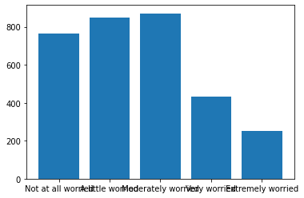

```python
plt.bar(mybars.index, mybars.values)
```

This plot leaves a lot of be desired. First, the category labels run into each other. To solve this problem, we can increase the size of the figure. We can change the size by typing

```
plt.figure(figsize(a,b))
```

prior to the call to `plt.bar()` or to another plotting function. Here `a` and `b` are numbers, in inches. If the window can't contain the proportions, the figure is scaled down proportionally. The [default dimensions](https://matplotlib.org/api/_as_gen/matplotlib.pyplot.figure.html) for a plot are 6.4 inches wide and 4.8 inches high. To create a figure 15 inches wide and 6 inches high, for example, we can type:

```
<BarContainer object of 5 artists>
```

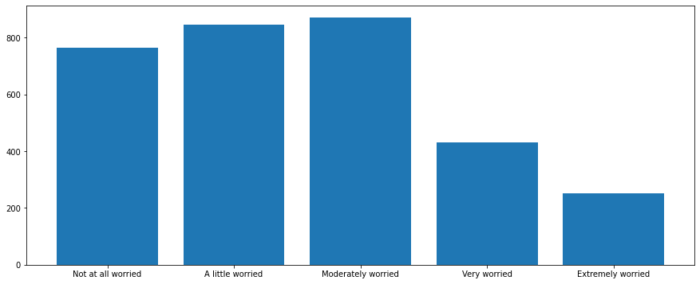

```python
plt.figure(figsize=(15, 6))
plt.bar(mybars.index, mybars.values)
```

Now we can clearly see the individual bar labels. Another way to accomodate longer bar labels is to orient the bars horizontally, leaving plenty of room for the labels on the left. To generate horizontal bars, First we use `plt.barh()` instead of `plt.bar()`:

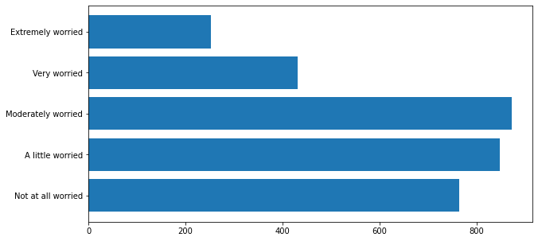

```python
plt.figure(figsize=(10, 5))
myplot = plt.barh(mybars.index, mybars.values)
```

There are many ways that we can make this figure more understandable. First, we can add axis labels. To add a label to the x and y axes, we type

```
plt.ylabel('a label')
plt.xlabel('another label')
```

after the call to `plt.bar()`, `plt.barh()`, or another plotting function. To add an overall title that will appear above the graph, we type

```
plt.title('a title')
```

after the plotting function. For example, we can add axis labels and a title to our horizontal barplot:

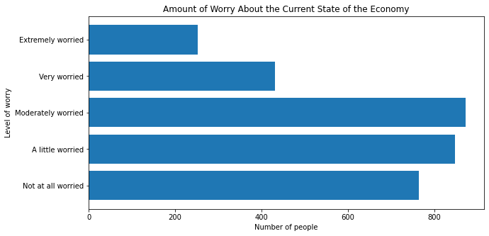

```python
plt.figure(figsize=(10, 5))
plt.barh(mybars.index, mybars.values)
plt.ylabel('Level of worry')
plt.xlabel('Number of people')
plt.title('Amount of Worry About the Current State of the Economy')
```

To change the color of the bars, use the `color` argument inside the plotting function. We can set the color of the bars to red, or to [many other colors](https://matplotlib.org/3.1.0/gallery/color/named_colors.html):

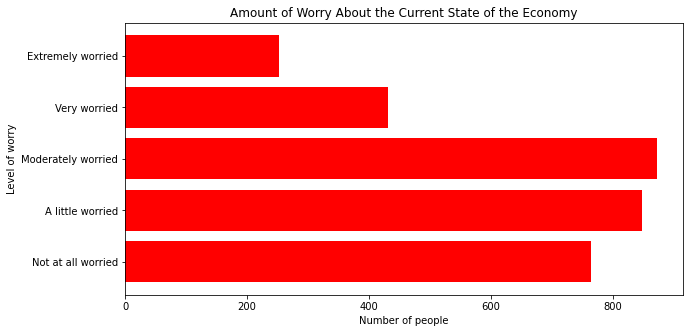

```python
plt.figure(figsize=(10, 5))
plt.barh(mybars.index, mybars.values, color='red')
plt.ylabel('Level of worry')
plt.xlabel('Number of people')
plt.title('Amount of Worry About the Current State of the Economy')
```

To set different colors for every bar, we can pass a list of colors. That's useful if we want to emphasize particular bars, such as the ones for "very worried" and "extremely worried":

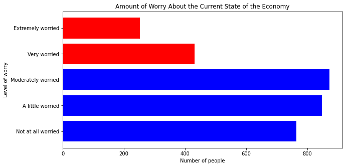

```python
plt.figure(figsize=(10, 5))
plt.barh(mybars.index, mybars.values, color=['blue', 'blue', 'blue', 'red', 'red'])
plt.ylabel('Level of worry')
plt.xlabel('Number of people')
plt.title('Amount of Worry About the Current State of the Economy')
```

To create a barplot with `seaborn`, we use the `sns.barplot()` function. There are two ways to use this function. We can pass a series directly to the `x` argument to define the categories and another series to the `y` argument to define the values:

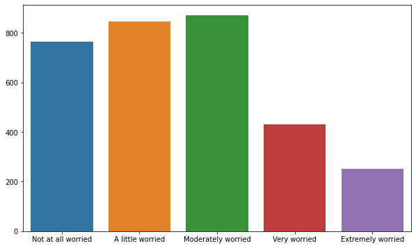

```python
plt.figure(figsize=(10, 6))
sns.barplot(x=mybars.index, y=mybars.values)
```

Alternatively, if the data exists in a dataframe, we can pass the x and y columns to the `x` and `y` arguments, and the dataframe to the `data` argument:

```python
mybars_df = mybars.reset_index()
mybars_df
```

|  | index | confecon |
| --- | --- | --- |
| 0 | Not at all worried | 764 |
| 1 | A little worried | 847 |
| 2 | Moderately worried | 871 |
| 3 | Very worried | 431 |
| 4 | Extremely worried | 252 |

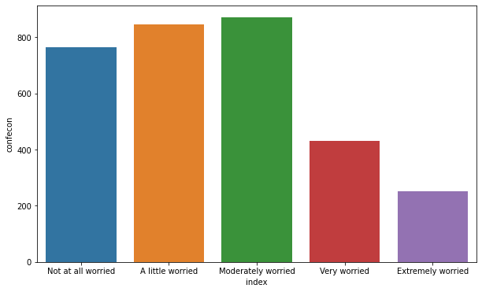

```python
plt.figure(figsize=(10, 6))
sns.barplot(x='index', y='confecon', data=mybars_df)
```

To orient a `seaborn` barplot horizontally, simply interchange the `x` and `y` features:

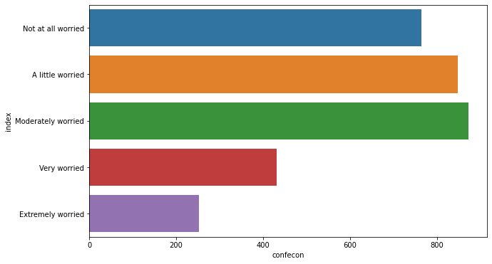

```python
plt.figure(figsize=(10, 6))
sns.barplot(x='confecon', y='index', data=mybars_df)
```

Notice that in the barplots above the axes are mislabeled. `seaborn` graphics use the same functions as `matplotlib` to change the title and axes:

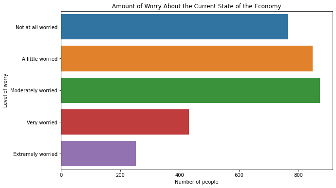

```python
plt.figure(figsize=(10, 6))
sns.barplot(x='confecon', y='index', data=mybars_df)
plt.ylabel('Level of worry')
plt.xlabel('Number of people')
plt.title('Amount of Worry About the Current State of the Economy')
```

Unlike `matplotlib`, `seaborn` uses different colors for each bar as a default simply because it is prettier. Edward Tufte would call this aesthetic choice "chartjunk", however, because the colors do not map to any additional feature or have any meaning other than being nicer to look at. Different colors are fine, but to change them, use the `palette` argument as follows:

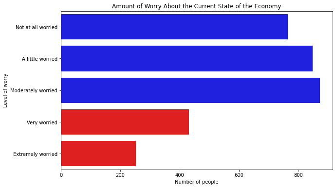

```python
plt.figure(figsize=(10, 6))
sns.barplot(x='confecon', y='index', data=mybars_df,
           palette = ['blue', 'blue', 'blue', 'red', 'red'])
plt.ylabel('Level of worry')
plt.xlabel('Number of people')
plt.title('Amount of Worry About the Current State of the Economy')
```

To create a barplot using the `.plot()` method in `pandas`, first save the values as a dataframe as we do with `mybars_df` above, then apply `.plot()` to this dataframe. `.plot()` has an argument `kind` that let's us specify the graph type. For a barplot, we write `kind='bar'` and we specify the x and y features the same way we did with `seaborn`:

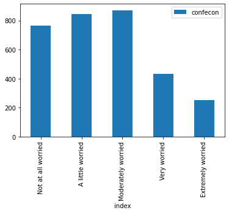

```python
mybars_df.plot(kind='bar', x='index', y='confecon')
```

Although `.plot()` uses `matplotlib` to generate its visualizations, it uses some different defaults. Note, for example, that the category labels are oriented vertically instead of horizontally to avoid overlapping labels.

`plt.figure(figsize=(10, 6))` does not work with the `.plot()` method, but this method includes a `figsize` argument:

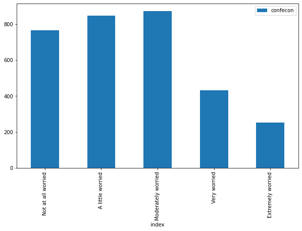

```python
mybars_df.plot(kind='bar', x='index', y='confecon',
              figsize = [10,6])
```

To create a horizontal bar plot, use `kind='barh'` instead of `kind='bar'`:

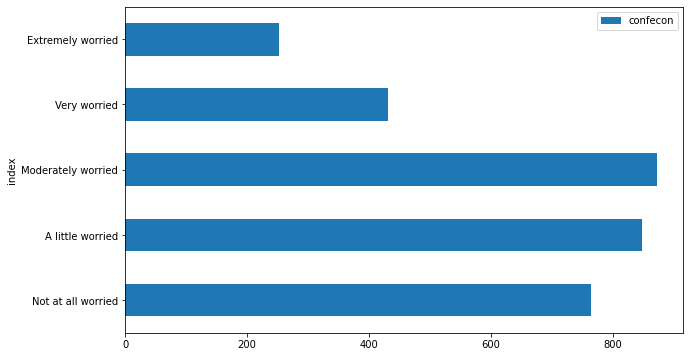

```python
mybars_df.plot(kind='barh', x='index', y='confecon',
              figsize = [10,6])
```

The `.plot()` method also uses the same `matplotlib` functions for setting the axis labels and title:

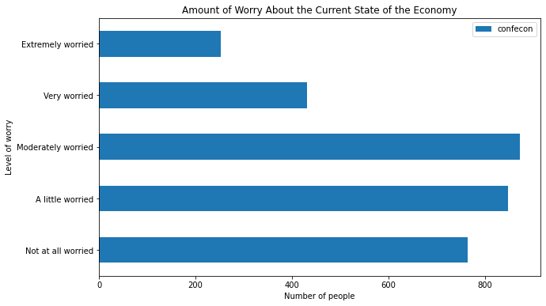

```python
mybars_df.plot(kind='barh', x='index', y='confecon',
              figsize = [10,6])
plt.ylabel('Level of worry')
plt.xlabel('Number of people')
plt.title('Amount of Worry About the Current State of the Economy')
```

To change the colors of the bars, use the `color` argument:

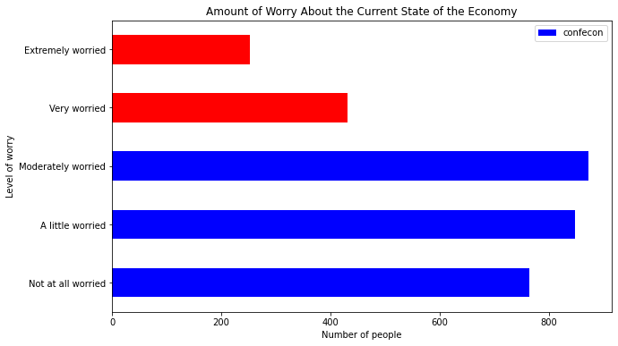

```python
mybars_df.plot(kind='barh', x='index', y='confecon',
              figsize = [10,6],
              color = ['blue', 'blue', 'blue', 'red', 'red'])
plt.ylabel('Level of worry')
plt.xlabel('Number of people')
plt.title('Amount of Worry About the Current State of the Economy')
```

Notice that there is a legend included by default. The legend will be important when we use the `.plot()` method to handle situations in which we stack bars or align them side-by-side for different groups. But in this case the legend is unnecessary. To turn off the legend, type `legend=False`:

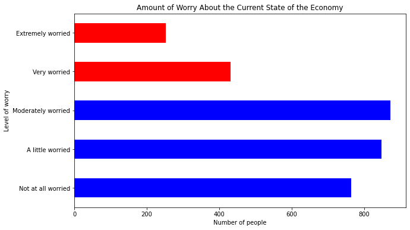

```python
mybars_df.plot(kind='barh', x='index', y='confecon',
              figsize = [10,6],
              color = ['blue', 'blue', 'blue', 'red', 'red'],
              legend = False)
plt.ylabel('Level of worry')
plt.xlabel('Number of people')
plt.title('Amount of Worry About the Current State of the Economy')
```

#### Barplots for Statistics Other Than Frequencies

A barplot does not have to simply illustrate frequencies. We can show any descriptive statistic in a barplot that can be calculated within each category. For example, we can show the average age of the people who responded with each level of economic worry. First we need to create a conditional means table and convert it to a dataframe with the `.reset_index()` method:

```python
mybars = anes.groupby('confecon').agg({'age':'mean'}).sort_index()
mybars_df = mybars.reset_index()
mybars_df
```

|  | confecon | age |
| --- | --- | --- |
| 0 | Not at all worried | 57.663613 |
| 1 | A little worried | 52.792208 |
| 2 | Moderately worried | 48.409874 |
| 3 | Very worried | 50.359629 |
| 4 | Extremely worried | 47.801587 |

Then we can plot these average ages using the same code we used for a barplot in `matplotlib`, `seaborn` or with the `.plot()` method. Here is a `matplotlib` barplot:

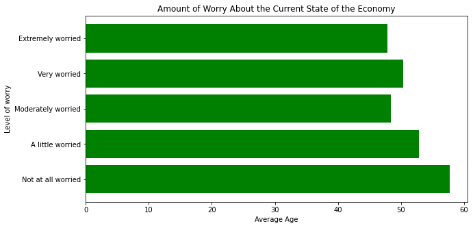

```python
plt.figure(figsize=(10, 5))
plt.barh(mybars_df.confecon, mybars_df.age, color='green')
plt.ylabel('Level of worry')
plt.xlabel('Average Age')
plt.title('Amount of Worry About the Current State of the Economy')
```

Here is a `seaborn` barplot:

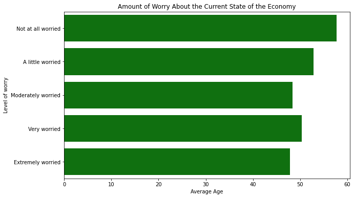

```python
plt.figure(figsize=(10, 6))
sns.barplot(x='age', y='confecon', data=mybars_df,
           palette = ['green'])
plt.ylabel('Level of worry')
plt.xlabel('Average Age')
plt.title('Amount of Worry About the Current State of the Economy')
```

And here is the barplot using `.plot()`:

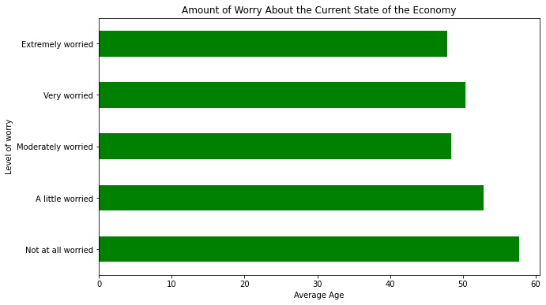

```python
mybars_df.plot(kind='barh', x='confecon', y='age',
              figsize = [10,6],
              color = 'green',
              legend = False)
plt.ylabel('Level of worry')
plt.xlabel('Average Age')
plt.title('Amount of Worry About the Current State of the Economy')
```

#### Annotating Bars with Values

We can annotate barplots with the heights of the bars, regardless of whether those bars are frequencies, means, or another descriptive statistic. Annotating barplots with values is tricky whether we use `matplotlib`, `seaborn`, or `.plot()`, but fortunately the same method will work for all three plotting tools.

First, we can use `plt.text()` to place text onto a figure. This function takes six arguments: the x and y coordinates where the text should be placed, the text, and `horizontalalignment='center'` and `verticalalignment='center'` to place the text box at the center of the specified (x,y) point (we can also specify left or right, or top or bottom), and `fontsize`. To place "Hello, world!" into the last figure, we can type:

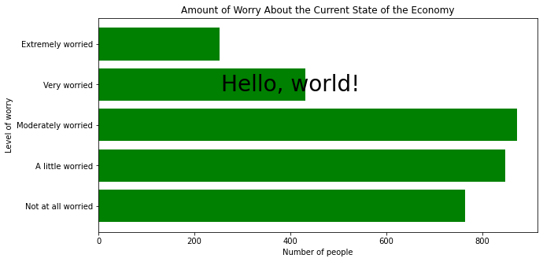

```python
mybars_df = anes.confecon.value_counts().sort_index().reset_index()

plt.figure(figsize=(10, 5))
plt.barh(mybars_df['index'], mybars_df['confecon'], color='green')
plt.ylabel('Level of worry')
plt.xlabel('Number of people')
plt.title('Amount of Worry About the Current State of the Economy')
plt.text(400, 3, 'Hello, world!', horizontalalignment='center', verticalalignment='center',
        fontsize=28)
```

We are going to use `plt.text()` to place values onto the bars, but we need to know the exact x and y-coordinates of the top or end of each bar. It is a mistake to try to find these coordinates through guessing and checking. Instead, rather than calling `plt.bar()` or another plotting function directly, we save it as a separate variable. The image will still display automatically in a Jupyter notebook, or after typing `plt.show()`. The variable has an attribute called `.patches`:

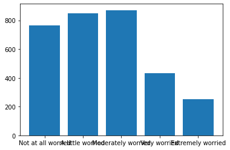

```python
myplot = plt.bar(mybars_df['index'], mybars_df['confecon'])
myplot.patches
```

The `.patches` attribute contains a list in which each item in the list looks like:

```
<matplotlib.patches.Rectangle at 0x1a391f0c50>
```

These codes are tags denoting the shapes that appear in the plot. There are five items in the list, one for each rectangle in this barplot. An individual rectangle has a method `.get_x()` that lists the x-coordinate of the left-edge of the rectangle, `.get_height()` that lists the y-coordinate of the top edge of the rectangle, and `.get_width()` that lists the width of each rectangle. These statistics for the first rectangle are:

```python
[myplot.patches[0].get_x(),
 myplot.patches[0].get_height(),
 myplot.patches[0].get_width()]
```

```
[-0.4, 764, 0.8]
```

We can loop across the rectangles in the `.patches` attribute, extract the x and y-coordinates for the values as well as the values themselves, and use `plt.text()` to place them onto the figure, as follows:

```
for rect in myplot.patches:
    xcoor = rect.get_x() + .5*rect.get_width()
    ycoor = rect.get_height()
    plt.text(xcoor, ycoor, str(ycoor),
             horizontalalignment='center',
             verticalalignment='bottom',
             fontsize=14)
```

This is a for-loop in which `rect` is the token that represents a single rectangle. `xcoor` is the x-coordinate for the value, which adds half the rectangle's width to be placed in the middle of the rectangle. `ycoor` is the y-coordinate and the value to be displayed, which we convert to text with `str()`. We set `horizontalalignment='center'` and `verticalalignment='bottom'` to ensure that the specified point exists on the bottom-middle of the text box: that places the numbers above the middle of each rectangle. Finally we repeat the process for every rectangle. For the barplot of economic confidence this approach yields the following output:

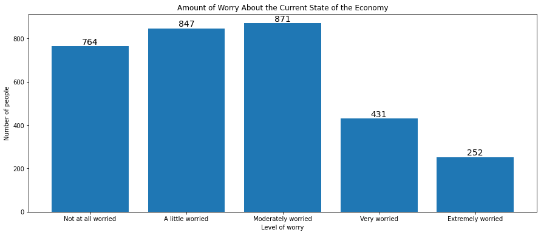

```python
plt.figure(figsize=(15, 6))
myplot = plt.bar(mybars_df['index'], mybars_df['confecon'])
plt.xlabel('Level of worry')
plt.ylabel('Number of people')
plt.title('Amount of Worry About the Current State of the Economy')
for rect in myplot.patches:
    xcoor = rect.get_x() + .5*rect.get_width()
    ycoor = rect.get_height()
    plt.text(xcoor, ycoor, str(ycoor),
             horizontalalignment='center',
             verticalalignment='bottom',
             fontsize=14)
```

To add labels to horizontal barplots, we use the same method, but we switch the x and y coordinates in `plt.text()` and we switch `.get_width()` and `.get_height()` to account for the new orientation:

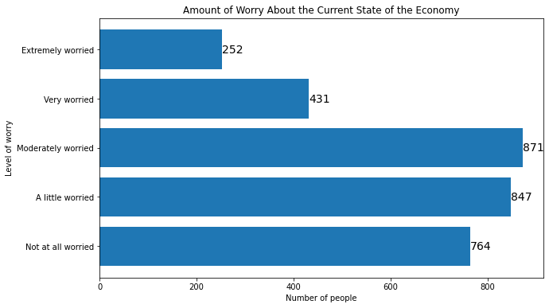

```python
plt.figure(figsize=(10, 6))
myplot = plt.barh(mybars_df['index'], mybars_df['confecon'])
plt.ylabel('Level of worry')
plt.xlabel('Number of people')
plt.title('Amount of Worry About the Current State of the Economy')
for rect in myplot.patches:
    xcoor = rect.get_y() + .5*rect.get_height()
    ycoor = rect.get_width()
    plt.text(ycoor, xcoor, str(ycoor),
             horizontalalignment='left',
             verticalalignment='center',
             fontsize=14)
```

This method can also be used to annotate the barplot with other descriptive statistics like the percent. We can calculate the percents inside the loop and use these in the text argument of `plt.text()`:

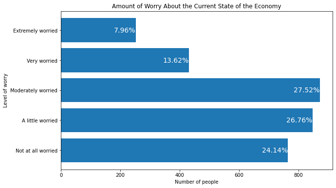

```python
plt.figure(figsize=(10, 6))
myplot = plt.barh(mybars_df['index'], mybars_df['confecon'])
plt.ylabel('Level of worry')
plt.xlabel('Number of people')
plt.title('Amount of Worry About the Current State of the Economy')
for rect in myplot.patches:
    xcoor = rect.get_y() + .5*rect.get_height()
    ycoor = rect.get_width()
    pcent = round(100*ycoor / sum(mybars_df['confecon']), 2)
    plt.text(ycoor, xcoor, str(pcent) + '%',
             horizontalalignment='right',
             verticalalignment='center',
             fontsize=14, color='white')
```

The same code works to label a `seaborn` barplot,

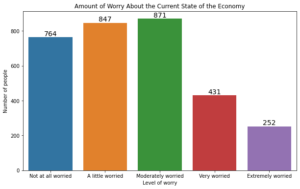

```python
plt.figure(figsize=(10, 6))
myplot = sns.barplot(x='index', y='confecon', data=mybars_df)
plt.xlabel('Level of worry')
plt.ylabel('Number of people')
plt.title('Amount of Worry About the Current State of the Economy')
for rect in myplot.patches:
    xcoor = rect.get_x() + .5*rect.get_width()
    ycoor = rect.get_height()
    plt.text(xcoor, ycoor, str(int(ycoor)),
             horizontalalignment='center',
             verticalalignment='bottom',
             fontsize=14)
```

and a horizontal `seaborn` barplot:

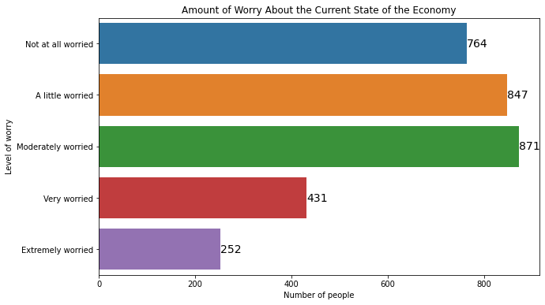

```python
plt.figure(figsize=(10, 6))
myplot = sns.barplot(x='confecon', y='index', data=mybars_df)
plt.ylabel('Level of worry')
plt.xlabel('Number of people')
plt.title('Amount of Worry About the Current State of the Economy')
for rect in myplot.patches:
    ycoor = rect.get_y() + .5*rect.get_height()
    xcoor = rect.get_width()
    plt.text(xcoor, ycoor, str(int(xcoor)),
             horizontalalignment='left',
             verticalalignment='center',
             fontsize=14)
```

The same methods also work for barplots generated with the `.plot()` method,

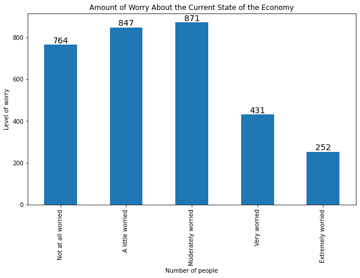

```python
myplot = mybars_df.plot(kind='bar', x='index', y='confecon',
              figsize = [10,6],
              legend = False)
plt.ylabel('Level of worry')
plt.xlabel('Number of people')
plt.title('Amount of Worry About the Current State of the Economy')
for rect in myplot.patches:
    xcoor = rect.get_x() + .5*rect.get_width()
    ycoor = rect.get_height()
    plt.text(xcoor, ycoor, str(int(ycoor)),
             horizontalalignment='center',
             verticalalignment='bottom',
             fontsize=14)
```

and for horizontal barplots generated with `.plot()`:

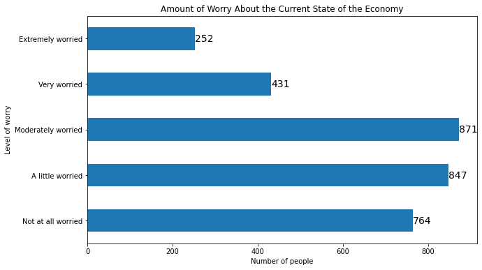

```python
myplot = mybars_df.plot(kind='barh', x='index', y='confecon',
              figsize = [10,6],
              legend = False)
plt.ylabel('Level of worry')
plt.xlabel('Number of people')
plt.title('Amount of Worry About the Current State of the Economy')
for rect in myplot.patches:
    ycoor = rect.get_y() + .5*rect.get_height()
    xcoor = rect.get_width()
    plt.text(xcoor, ycoor, str(int(xcoor)),
             horizontalalignment='left',
             verticalalignment='center',
             fontsize=14)
```